# Want population level inferences? Use sum-to-zero contrasts

Andrew J. Tyre & Trevor Hefley

September 23, 2017

# Introduction

A sum-to-zero contrast codes a categorical variable as deviations from a grand mean. Social scientists use them extensively. Should ecologists?[^1]

More accurately, should I tell my students in Ecological Statistics to use them? Sum-to-zero contrasts are conceptually similar to centering a continuous variable by subtracting the mean from your predictor variable prior to analysis. Discussions of centering often end up conflated with *scaling*, which is dividing your predictor variable by a constant, usually the standard deviation, prior to analysis. *Always scaling* covariates prior to regression analysis is controversial advice. See for example [Andrew Gelman’s blogpost and comments](http://andrewgelman.com/2009/07/11/when_to_standar/), or many crossvalidated questions [such as this one](http://stats.stackexchange.com/q/29781/12258) which has links to many others. There is a good reference as well as some useful discussion in the comments of [this question](http://stats.stackexchange.com/questions/179732/motivation-to-center-continuous-predictor-in-multiple-regression-for-sake-of-mul). In this post I focus on the effects of sum to zero contrasts for categorical variables and interactions with continuous variables.[^2]

Here is my summary of the pros and cons of centering drawn from those references above.

- Centering continuous variables eliminates collinearity between interaction and polynomial terms and the individual covariates that make them up.
- Centering does not affect inference about the covariates.
- Centering can improve the interpretability of the coefficients in a regression model, particularly because the intercept represents the value of the response at the mean of the predictor variables.
- Predicting out of sample data with a model fitted to centered data must be done carefully because the center of the out of sample data will be different from the fitted data.
- There may be some constant value other than the sample mean that makes more sense based on domain knowledge.

# A simple example

To make the discussion concrete, let me demonstrate with an example of the interaction between a continuous covariate and a categorical one. In the following I refer to the effect of individual covariates outside the interaction as the “simple effect” of that covariate.

```r
data(iris)
# flip the treatment contrast so coefficient labels match
new_contrast <- contr.SAS(3)
colnames(new_contrast) <- c("setosa", "versicolor")
contrasts(iris$Species) <- new_contrast

m0 <- lm(Sepal.Width ~ Sepal.Length * Species, data = iris)
summary_m0 <- summary(m0)
iris_centered <- iris %>% mutate(Sepal.Length = Sepal.Length - mean(Sepal.Length))
m1 <- lm(Sepal.Width ~ Sepal.Length * Species, data = iris_centered)
summary_m1 <- summary(m1)
iris_csz <- iris_centered
sum_contrast <- contr.sum(3)
colnames(sum_contrast) <- colnames(new_contrast)
contrasts(iris_csz$Species) <- sum_contrast
m2 <- lm(Sepal.Width ~ Sepal.Length * Species, data = iris_csz)
summary_m2 <- summary(m2)
m3 <- lm(Sepal.Width ~ Sepal.Length, data = iris_csz)
summary_m3 <- summary(m3)
m4 <- lm(Sepal.Width ~ Sepal.Length + Species, data = iris_csz)
summary_m4 <- summary(m4)

tableout <- huxreg(Interaction = m0, `Interaction and centered` = m1, `Interaction, centered, and sum-to-zero` = m2,
    `Length only` = m3, `Length and Species` = m4)

caption(tableout) <- "(#tab:regTable) Linear regressions of Sepal Width on species and Sepal Length for different parameterizations. The default treatment contrast has been changed to match the SAS default so that covariate labels match between the treatment and sum-to-zero contrasts."
# tableout <- stargazer(m0, m1, m2, m3, m4, type = 'html', column.labels =
# c('Interaction', 'Interaction and Centered', 'Interaction, centered and
# sum-to-zero', 'Length only', 'Length and Species'), intercept.bottom =
# FALSE, intercept.top = TRUE, keep.stat = c('adj.rsq', 'ser'), align=TRUE,
# style = 'ajs' # 'ajs' )
tableout
```

(#tab:regTable) Linear regressions of Sepal Width on species and Sepal Length for different parameterizations. The default treatment contrast has been changed to match the SAS default so that covariate labels match between the treatment and sum-to-zero contrasts.

|  | Interaction | Interaction and centered | Interaction, centered, and sum-to-zero | Length only | Length and Species |
| --- | --- | --- | --- | --- | --- |
| (Intercept) | 1.446 *** | 2.801 *** | 3.213 *** | 3.057 *** | 3.057 *** |
|  | (0.405) | (0.060) | (0.041) | (0.035) | (0.024) |
| Sepal.Length | 0.232 *** | 0.232 *** | 0.450 *** | -0.062 | 0.350 *** |
|  | (0.061) | (0.061) | (0.049) | (0.043) | (0.046) |
| Speciessetosa | -2.016 ** | 1.295 *** | 0.884 *** |  | 0.664 *** |
|  | (0.686) | (0.117) | (0.071) |  | (0.051) |
| Speciesversicolor | -0.574 | -0.061 | -0.472 *** |  | -0.320 *** |
|  | (0.605) | (0.071) | (0.047) |  | (0.034) |
| Sepal.Length:Speciessetosa | 0.567 *** | 0.567 *** | 0.348 *** |  |  |
|  | (0.126) | (0.126) | (0.080) |  |  |
| Sepal.Length:Speciesversicolor | 0.088 | 0.088 | -0.130 * |  |  |
|  | (0.097) | (0.097) | (0.066) |  |  |
| N | 150 | 150 | 150 | 150 | 150 |
| R2 | 0.623 | 0.623 | 0.623 | 0.014 | 0.569 |
| logLik | -14.671 | -14.671 | -14.671 | -86.732 | -24.609 |
| AIC | 43.342 | 43.342 | 43.342 | 179.464 | 59.217 |
| *** p < 0.001; ** p < 0.01; * p < 0.05. |  |  |  |  |  |

The intercept of the interaction model isn’t directly interpretable because it gives the average width at a length of zero, which is impossible. In addition, both the intercept and simple effect of length represent the change in width for only one species, *virginica*. The treatment contrast in R estimates coefficients for $k - 1$ levels of a factor. In the simple effect of a factor each coefficient is the difference between the last level (estimated by the intercept), and the named level. In the above, `Speciessetosa` has sepals that are 2 mm narrower than *virginica* at a length of zero. The interaction coefficients such as `Sepal.Length:Speciessetosa` tell us how much the effect of Sepal.Length in *setosa* changes from that in *virginica*. So every mm of sepal length in *setosa* increases sepal width by $.23 + .57 = 0.8$ mm.

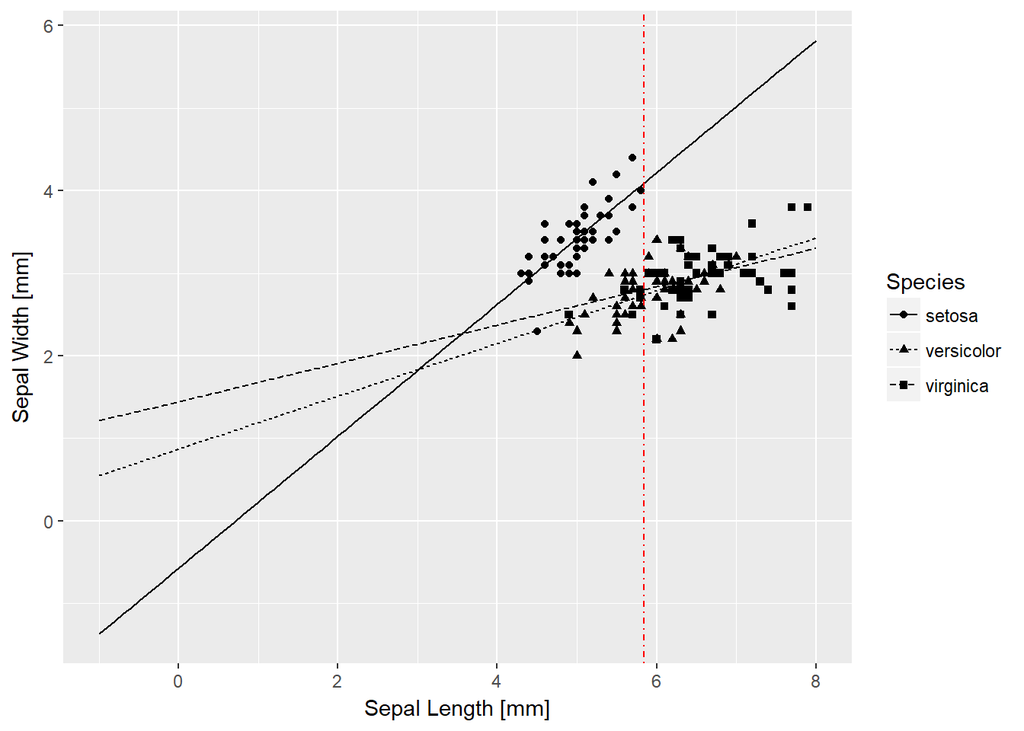

Figure 1: Sepal Length against Sepal Width for three species of iris.

```r
base_iris <- ggplot(iris, aes(x = Sepal.Length, y = Sepal.Width)) + geom_point(aes(shape = Species)) +
    xlab("Sepal Length [mm]") + ylab("Sepal Width [mm]")

nd <- expand.grid(Sepal.Length = seq(-1, 8, 0.1), Species = factor(levels(iris$Species)))
pred.0 <- augment(m0, newdata = nd)
base_iris + geom_line(aes(y = .fitted, linetype = Species), data = pred.0) +
    geom_vline(xintercept = mean(iris$Sepal.Length), color = "red", linetype = 4)
```

I did something rather silly in Figure 1 because I wanted to see where the curves cross x = 0. That is where the estimates for the intercept and simple effect of species are calculated. The intercept is positive, and the line for *virginica* crosses x = 0 well above y = 0. The simple effect estimates of Species are both negative, with *setosa* being larger, and indeed the line for *setosa* crosses x = 0 at the lowest point. Similarly, the simple effect of length is the slope of the line for *virginica*, and it is smaller than the slopes of the other two species because the estimated interactions are both positive. But not centering really makes things ugly for direct interpretation of the estimated coefficients.

Now we repeat the analysis after centering `sepal.length`. The estimates and the standard errors for the continuous covariate, including the interaction terms, do not change. The slopes of the three lines are not affected by centering the continuous variable. The estimates and standard errors for the intercept and simple effect of species do change. That’s OK, because they are really testing something quite different from before. Now these coefficients are telling us what happens at the mean sepal length. Looking back at Figure 1, the mean is a bit less than 6 mm, *versicolor* is about the same size as *virginica*, while *setosa* is quite a bit bigger. And that’s what the simple effects coefficients tell us in the centered model (2nd column of Table 1). The coefficient for *setosa* is large (relative to SE) and positive, while the coefficient for *versicolor* is small and negative.

What happens if we use sum to zero contrasts for species? I can now directly interpret the intercept as the average width at the average length, averaged over species. Similarly the simple effect of length as the change in width averaged across species. This seems like a very useful set of coefficients to look at, particularly if my categorical covariate has many levels. You might ask (I did), what do the categorical coefficients mean? They represent deviations from the mean intercept for each species. OK, you say (I did), then where’s species *virginica*? After much head scratching, the answer is that it is the negative of the **sum** of the other two coefficients.

I just thought of something else. Are those “average” intercept and slope the same as what I would get if I only use `Sepal.Length`? Whoa! It is not the same, in fact it is radically different. Totally different conclusion about the “average” effect. So, an “average” while admitting that species differ is very different from assuming there is no difference between species. That makes sense, I guess.

## Interpreting non-marginal effects

I have seen assertions in some papers (particularly from social sciences), that using sum to zero contrasts (also called effects coding, I believe), allows the direct interpretation of lower order terms in an ANOVA table even in the presence of interactions.

```r
at <- as.data.frame(anova(m2))  # doesn't matter which model I use
at <- hux(at)
at <- add_rownames(at, "")
at <- add_colnames(at)
caption(at) <- "(#tab:ANOVAtable) Analysis of variance table for model M2, with continuous variable centered and sum to zero categorical variable."
at
```

(#tab:ANOVAtable) Analysis of variance table for model M2, with continuous variable centered and sum to zero categorical variable.

|  | Df | Sum.Sq | Mean.Sq | F.value | Pr..F. |
| --- | --- | --- | --- | --- | --- |
| Sepal.Length | 1.00 | 0.39 | 0.39 | 5.28 | 0.02 |
| Species | 2.00 | 15.72 | 7.86 | 105.99 | 0.00 |
| Sepal.Length:Species | 2.00 | 1.51 | 0.76 | 10.20 | 0.00 |
| Residuals | 144.00 | 10.68 | 0.07 |  |  |

If so, in this case I could say “Sepal Width differs significantly between species.” I’m not sure I believe that. Table 2 is identical between all 3 models, whether I use sum-to-zero contrasts or not. Why should the interpretation differ if I just change the parameterization of the model?

# Population level inference: sum to zero vs. random effect.

Deguines et al. (2017) published an interesting dataset of abundances and densities of different species on multiple plots in multiple years. The key question was how does density of each species respond to both precipitation and the presence or abundance of other species. Here I will focus on just one species and compare two different ways of getting at the precipitation response in an “average” plot.

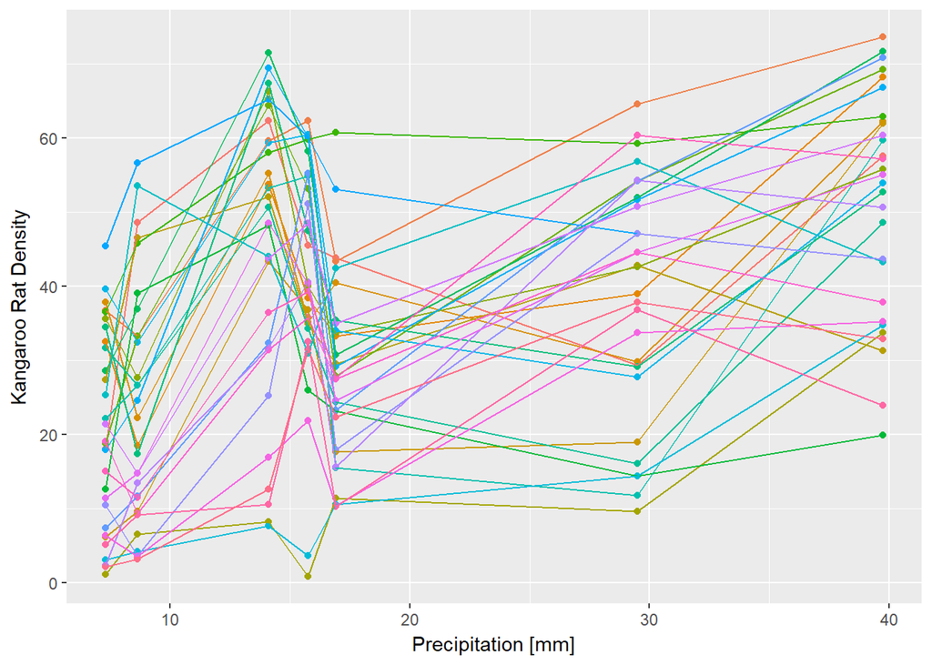

Figure 2: Kangaroo rat density as a function of precipitation for 30 plots in 7 years.

```r
deguines <- read.csv("http://datadryad.org/bitstream/handle/10255/dryad.131841/Deguines_etal_JAE_carrizo.csv?sequence=1")
ggplot(deguines, mapping = aes(x = Precip, y = Krats, color = plot_id)) + geom_point() +
    geom_line() + guides(color = FALSE) + xlab("Precipitation [mm]") + ylab("Kangaroo Rat Density")
```

Deguines et al. did a thorough job of evaluating the assumptions of the model estimated using `lme()`, so we will simply start with their top model, which had an interaction between precipitation and plant biomass, a random effect of plot identity, and allowed the variance to change between years. The only thing I will change is that I will center the two continuous variables to ease the interpretation of the population average effects.

```r
library(nlme)
```

```r
# centering
deguines_c <- deguines %>% mutate(Precip = Precip - mean(Precip), Plant_biomass = Plant_biomass -
    mean(Plant_biomass))

# Specifying control values for lme fit:
lmecontr_foc <- lmeControl(maxIter = 50, msMaxIter = 50)  #the default

mixedmod <- lme(Krats ~ Precip * Plant_biomass, weights = varIdent(form = ~1 |
    fyear), random = ~1 | plot_id, data = deguines_c, method = "REML", control = lmecontr_foc)
summary(mixedmod)
```

```
## Linear mixed-effects model fit by REML
##  Data: deguines_c
##        AIC      BIC    logLik
##   1714.854 1754.789 -845.4271
##
## Random effects:
##  Formula: ~1 | plot_id
##         (Intercept) Residual
## StdDev:    11.16899 10.99395
##
## Variance function:
##  Structure: Different standard deviations per stratum
##  Formula: ~1 | fyear
##  Parameter estimates:
##     f2007     f2008     f2009     f2010     f2011     f2012     f2013
## 1.0000000 1.8577098 1.4318897 1.3127837 1.1022841 0.5910152 0.6527095
## Fixed effects: Krats ~ Precip * Plant_biomass
##                         Value Std.Error  DF   t-value p-value
## (Intercept)          33.43609 2.2318267 177 14.981490  0.0000
## Precip                0.98271 0.0975694 177 10.071930  0.0000
## Plant_biomass        -0.43972 1.3226431 177 -0.332459  0.7399
## Precip:Plant_biomass -0.24273 0.1140585 177 -2.128152  0.0347
##  Correlation:
##                      (Intr) Precip Plnt_b
## Precip                0.141
## Plant_biomass         0.007 -0.600
## Precip:Plant_biomass -0.239 -0.473  0.247
##
## Standardized Within-Group Residuals:
##        Min         Q1        Med         Q3        Max
## -1.8654047 -0.6230783  0.1618276  0.8452083  1.9621821
##
## Number of Observations: 210
## Number of Groups: 30
```

Now I will re-fit the model treating `plot_id` as a sum-to-zero contrast fixed effect.

```r
contrasts(deguines_c$plot_id) <- contr.sum(30)
szmodel <- lm(Krats ~ Precip * Plant_biomass + plot_id, data = deguines_c)
sztable <- huxreg(szmodel)
caption(sztable) <- "(#tab:sz-model) Regression output for the sum to zero model of Kangaroo Rat density."
sztable
```

(#tab:sz-model) Regression output for the sum to zero model of Kangaroo Rat density.

|  | (1) |
| --- | --- |
| (Intercept) | 38.369 *** |
|  | (1.128) |
| Precip | 1.124 *** |
|  | (0.131) |
| Plant_biomass | -3.126 |
|  | (1.731) |
| plot_id1 | 9.337 |
|  | (4.744) |
| plot_id2 | 17.666 *** |
|  | (4.715) |
| plot_id3 | 3.665 |
|  | (4.744) |
| plot_id4 | 3.570 |
|  | (4.726) |
| plot_id5 | -6.623 |
|  | (4.713) |
| plot_id6 | 2.193 |
|  | (4.809) |
| plot_id7 | -24.443 *** |
|  | (4.720) |
| plot_id8 | 8.651 |
|  | (4.706) |
| plot_id9 | 10.230 * |
|  | (4.716) |
| plot_id10 | 19.716 *** |
|  | (4.721) |
| plot_id11 | -7.239 |
|  | (4.817) |
| plot_id12 | 16.467 *** |
|  | (4.733) |
| plot_id13 | 5.554 |
|  | (4.707) |
| plot_id14 | -3.183 |
|  | (4.708) |
| plot_id15 | -2.549 |
|  | (4.718) |
| plot_id16 | 7.961 |
|  | (4.710) |
| plot_id17 | -24.680 *** |
|  | (4.707) |
| plot_id18 | 9.608 * |
|  | (4.720) |
| plot_id19 | 10.814 * |
|  | (4.758) |
| plot_id20 | 19.430 *** |
|  | (4.725) |
| plot_id21 | -1.960 |
|  | (4.855) |
| plot_id22 | -7.210 |
|  | (4.852) |
| plot_id23 | -6.394 |
|  | (4.708) |
| plot_id24 | 3.147 |
|  | (4.707) |
| plot_id25 | -3.920 |
|  | (4.752) |
| plot_id26 | -17.803 *** |
|  | (4.822) |
| plot_id27 | -7.005 |
|  | (4.705) |
| plot_id28 | -1.026 |
|  | (4.709) |
| plot_id29 | -18.077 *** |
|  | (4.767) |
| Precip:Plant_biomass | -0.609 *** |
|  | (0.155) |
| N | 210 |
| R2 | 0.614 |
| logLik | -812.790 |
| AIC | 1693.579 |
| *** p < 0.001; ** p < 0.01; * p < 0.05. |  |

Looking at the coefficients we are seeing a very similar interpretation emerging. If we plot the random effect estimates against the plot coefficients we see there is a close correspondence (Figure 3), but in general the random effects estimates are smaller. This is “shrinkage” towards zero, caused by assuming the random effects come from a normal distribution.

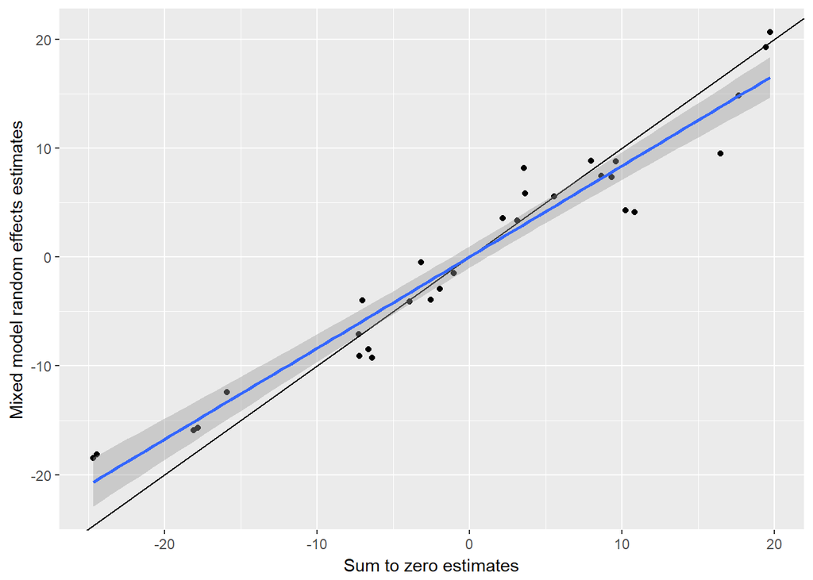

Figure 3: Random effects of each plot versus the estimated fixed effect for each plot. Solid black line is the 1:1 line.

```r
mixedmod_effects <- tidy(mixedmod, effects = "fixed")
plot_id_mm <- ranef(mixedmod)
# promote rownames to a column
plot_id_mm <- mutate(plot_id_mm, term = "(Intercept)", group = "plot_id", level = rownames(plot_id_mm)) %>%
    rename(estimate = `(Intercept)`)
szmodel_effects <- tidy(szmodel)
# need to add group and level to fixed_effects, and convert to estimates for
# all groups extract sz coefs into seperate data frame
plot_id_sz <- filter(szmodel_effects, startsWith(szmodel_effects$term, "plot_id"))
szmodel_effects <- filter(szmodel_effects, !startsWith(szmodel_effects$term,
    "plot_id"))
# add group and level columns
contrmatrix <- contrasts(deguines_c$plot_id)
# add empty row see
# https://stackoverflow.com/questions/41151350/append-empty-row-to-a-dataframe
plot_id_sz[nrow(plot_id_sz) + 1, ] <- NA
plot_id_sz <- mutate(plot_id_sz, term = "(Intercept)", group = "plot_id", level = rownames(contrmatrix))
# calculate estimated coef for final row
plot_id_sz[nrow(plot_id_sz), "estimate"] <- -sum(plot_id_sz$estimate[-nrow(plot_id_sz)])
# SE involves the estimated vcov matrix ... leave that out for now.
names(plot_id_mm) <- paste0(names(plot_id_mm), ".mm")
names(plot_id_sz) <- paste0(names(plot_id_sz), ".sz")
plot_id_effects <- bind_cols(plot_id_mm, plot_id_sz)
ggplot(data = plot_id_effects, mapping = aes(x = estimate.sz, y = estimate.mm)) +
    geom_point() + geom_abline(slope = 1, intercept = 0) + geom_smooth(method = "lm") +
    xlab("Sum to zero estimates") + ylab("Mixed model random effects estimates")
```

There is another thing that is easy to do with the sum to zero estimates that is harder with the mixed model. We can ask if each individual plot is different from the population average! That is the p value in Table 3.

# Making population average predictions

Often we want to make predictions about the next plot observed, which can be done in a mixed model context, although statisticians disagree on which variances to include in such predictions. It isn’t immediately obvious how to make such predictions from a model with sum-to-zero contrasts. We could use a truncated version of the design matrix, just the columns from the population level covariates, but that would leave out the variance associated with different plots. Instead, we could make predictions from *all* plots, and then average those predictions. The variance of the predicted values would be averaged as well, and we could include a component that accounts for the between plot variation by using the same trick as the unconditional variance in AIC based model averaging.

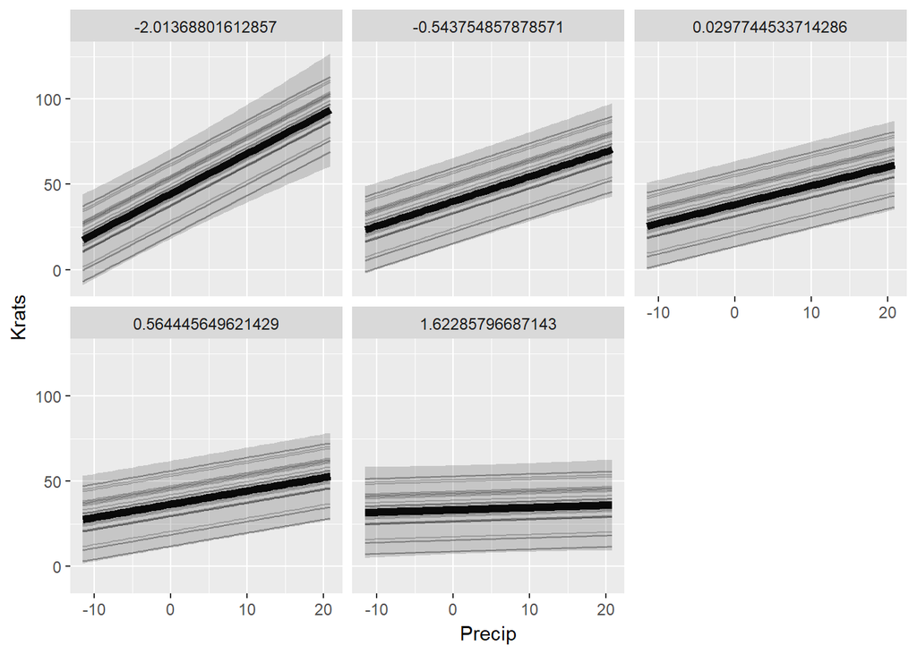

Figure 4: Kangaroo rats increase with increasing precipitation, but the effect decreases with increasing plant biomass. The heavy black line is the population average prediction, each of the light grey lines shows the prediction for a single plot. The solid ribbon shows approximate 95% confidence limits on the population average prediction.

```r
nd <- crossing(Precip = seq(min(deguines_c$Precip), max(deguines_c$Precip),
    length.out = 50), Plant_biomass = quantile(deguines_c$Plant_biomass), plot_id = levels(deguines_c$plot_id))

preddata <- augment(szmodel, newdata = nd)
predavg <- preddata %>% group_by(Plant_biomass, Precip) %>% mutate(var_fitted = .se.fit^2) %>%
    summarize(Krats = mean(.fitted), var_Krats = sum(var_fitted + (.fitted -
        Krats)^2)/n(), se_Krats = sqrt(var_Krats))
ggplot(predavg, aes(x = Precip)) + geom_line(aes(y = Krats), size = 2) + geom_ribbon(aes(ymin = Krats -
    1.96 * se_Krats, ymax = Krats + 1.96 * se_Krats), alpha = 0.2) + facet_wrap(~Plant_biomass) +
    geom_line(data = preddata, mapping = aes(y = .fitted, group = plot_id),
        alpha = 0.2)
```

Rough 95% confidence limits for the population level prediction include all the plot level predictions (Figure 4).

- How does this variance compare with the between plot variance in mixed model?
- Make the same plot using the mixed model?
- change axes back to original data
- add raw observations to plot?
- fix panel headings

Deguines, Nicolas, Justin S. Brashares, and Laura R. Prugh. 2017. “Precipitation Alters Interactions in a Grassland Ecological Community.” *Journal of Animal Ecology* 86 (2): 262–72. doi:10.1111/1365-2656.12614.

[^1]: This stuff first appeared [as a question on CrossValidated](http://stats.stackexchange.com/questions/188852/centering-in-the-presence-of-interactions-with-categorical-predictors), but received no attention. Then AJT made it into [a blog post](http://atyre2.github.io/2016/09/03/sum-to-zero-contrasts.html), where it still received no attention! Upping the ante here …
[^2]: All the code for this post, including that not shown, [can be found here](https://github.com/atyre2/population-inference/raw/master/index.Rmd).